# Udacity DSND Capstone Project

# Sparkify - Table of contents

1. Project Definition & Overview
2. Importing packages and setup
3. Load and Clean Dataset
   1. Loading data - spark session
   2. First look at data
   3. Cleaning data
4. Exploratory Data Analysis
   1. Defining Churn
      1. Cancellation Confirmation Events
      2. Downgrade Events
   2. Explore Data
5. Feature Engineering
6. Modeling
   1. Loading Data
   2. Scaling and splitting
   3. Training (with hyperparameter tuning) and Predicting
   4. Final Result
7. Conlusion

# 1. Project Definition & Overview

#### Intro

Sparkify is a music streaming service (similar to Apple Music and Spotify), and can be used for free, or if the customer wants there are also paid plans which eliminate advertising.

The data provided is the log of the users interactions with the service/application. Every event/interaction is recorded with the following information:

```
root
 |-- artist: string (nullable = true)
 |-- auth: string (nullable = true)
 |-- firstName: string (nullable = true)
 |-- gender: string (nullable = true)
 |-- itemInSession: long (nullable = true)
 |-- lastName: string (nullable = true)
 |-- length: double (nullable = true)
 |-- level: string (nullable = true)
 |-- location: string (nullable = true)
 |-- method: string (nullable = true)
 |-- page: string (nullable = true)
 |-- registration: long (nullable = true)
 |-- sessionId: long (nullable = true)
 |-- song: string (nullable = true)
 |-- status: long (nullable = true)
 |-- ts: long (nullable = true)
 |-- userAgent: string (nullable = true)
 |-- userId: string (nullable = true)
```

This project has 4 main stages:

1. Loading and cleaning data
   1. Load dataset
   2. Cleaning missing or invalid data
2. Exploratory Data Analysis
   1. Define Churn & Downgrades from the original features
   2. Explore data (analysing interactions from both type of users: those who churned and those who didn't)
3. Feature Engineering
   1. Build meaningfull features from the original dataset for each user, that represent the overall experience in Sparkify
   2. Save final dataset with engineered features
4. Model training and Prediction
   1. Split data into training and testing data sets
   2. Train several classification models & Hyperparameter tunning with Grid Search
   3. Select best machine learning model based on f1score

In this project I'll be using Spark (PySpark) for all the data manipulation, loading, cleaning, feature engineering and Machine Learning. This workspace contains a tiny subset (128MB) of the full dataset available (12GB). This workspace is used to build the project, or to explore a smaller subset with Spark. The code can then be deployed on the cloud.

#### Problem Definition

The aim of this project is to predict customer churn based on its usage history/log. For that purpose it will be needed to generate new meaningfull features that characterize user experience in Sparkify, so that we can use a machine learning model to predict which customers are likely to churn.

For the prediction part I'll be using use F1 score to select the best machine learning model since the churned users are a fairly small subset (highly imbalanced dataset).

# 2. Importing packages and setup

Loading packages and creating spark session

```python
# import libraries
import seaborn as sns
import pandas as pd
import numpy as np
from matplotlib import pyplot as plt
import datetime
%matplotlib inline

# pyspark
from pyspark.sql import SparkSession
from pyspark.sql.functions import col, countDistinct, sum, avg, when
from pyspark.sql.functions import udf
from pyspark.sql.types import StringType
from pyspark.sql.types import IntegerType, FloatType
from pyspark.sql import Window
from pyspark.ml.feature import Normalizer, StandardScaler, VectorAssembler
from pyspark.ml.tuning import CrossValidator, ParamGridBuilder
from pyspark.ml.classification import LogisticRegression, GBTClassifier, LinearSVC, RandomForestClassifier, DecisionTreeClassifier
from pyspark.ml.evaluation import MulticlassClassificationEvaluator
```

```python
# create a Spark session
spark_session = SparkSession.builder.appName("Sparkify").getOrCreate()
```

# 3.Load and Clean Dataset

In this workspace, the mini-dataset file is `mini_sparkify_event_data.json`. Load and clean the dataset, checking for invalid or missing data - for example, records without userids or sessionids.

### 3.A) Loading data - spark session

Loading data from the mini-dataset file with pyspark.

```python
# Loading data
df = spark_session.read.json('mini_sparkify_event_data.json')
```

### 3.B) First look at data

Taking a first look at data: features/columns names, possible values by features, distinct users (userid).

```python
# Printing first lines of 'df' dataframe
df.show(n=2, truncate=False, vertical=True)
```

```
-RECORD 0------------------------------------------------------------------------------------------------------------------------
 artist        | Martha Tilston
 auth          | Logged In
 firstName     | Colin
 gender        | M
 itemInSession | 50
 lastName      | Freeman
 length        | 277.89016
 level         | paid
 location      | Bakersfield, CA
 method        | PUT
 page          | NextSong
 registration  | 1538173362000
 sessionId     | 29
 song          | Rockpools
 status        | 200
 ts            | 1538352117000
 userAgent     | Mozilla/5.0 (Windows NT 6.1; WOW64; rv:31.0) Gecko/20100101 Firefox/31.0
 userId        | 30
-RECORD 1------------------------------------------------------------------------------------------------------------------------
 artist        | Five Iron Frenzy
 auth          | Logged In
 firstName     | Micah
 gender        | M
 itemInSession | 79
 lastName      | Long
 length        | 236.09424
 level         | free
 location      | Boston-Cambridge-Newton, MA-NH
 method        | PUT
 page          | NextSong
 registration  | 1538331630000
 sessionId     | 8
 song          | Canada
 status        | 200
 ts            | 1538352180000
 userAgent     | "Mozilla/5.0 (Windows NT 6.1; WOW64) AppleWebKit/537.36 (KHTML, like Gecko) Chrome/37.0.2062.103 Safari/537.36"
 userId        | 9
only showing top 2 rows
```

```python
# Print schema
df.printSchema()
```

```
root
 |-- artist: string (nullable = true)
 |-- auth: string (nullable = true)
 |-- firstName: string (nullable = true)
 |-- gender: string (nullable = true)
 |-- itemInSession: long (nullable = true)
 |-- lastName: string (nullable = true)
 |-- length: double (nullable = true)
 |-- level: string (nullable = true)
 |-- location: string (nullable = true)
 |-- method: string (nullable = true)
 |-- page: string (nullable = true)
 |-- registration: long (nullable = true)
 |-- sessionId: long (nullable = true)
 |-- song: string (nullable = true)
 |-- status: long (nullable = true)
 |-- ts: long (nullable = true)
 |-- userAgent: string (nullable = true)
 |-- userId: string (nullable = true)
```

```python
# Converting to pandas dataframe for better visualization (limiting to 10 rows for low memory usage)
df_pandas = df.limit(10).toPandas()
```

```python
# Printing first 10 rows
df_pandas.head(10)
```

|  | artist | auth | firstName | gender | itemInSession | lastName | length | level | location | method | page | registration | sessionId | song | status | ts | userAgent | userId |
| --- | --- | --- | --- | --- | --- | --- | --- | --- | --- | --- | --- | --- | --- | --- | --- | --- | --- | --- |
| 0 | Martha Tilston | Logged In | Colin | M | 50 | Freeman | 277.89016 | paid | Bakersfield, CA | PUT | NextSong | 1538173362000 | 29 | Rockpools | 200 | 1538352117000 | Mozilla/5.0 (Windows NT 6.1; WOW64; rv:31.0) G... | 30 |
| 1 | Five Iron Frenzy | Logged In | Micah | M | 79 | Long | 236.09424 | free | Boston-Cambridge-Newton, MA-NH | PUT | NextSong | 1538331630000 | 8 | Canada | 200 | 1538352180000 | "Mozilla/5.0 (Windows NT 6.1; WOW64) AppleWebK... | 9 |
| 2 | Adam Lambert | Logged In | Colin | M | 51 | Freeman | 282.82730 | paid | Bakersfield, CA | PUT | NextSong | 1538173362000 | 29 | Time For Miracles | 200 | 1538352394000 | Mozilla/5.0 (Windows NT 6.1; WOW64; rv:31.0) G... | 30 |
| 3 | Enigma | Logged In | Micah | M | 80 | Long | 262.71302 | free | Boston-Cambridge-Newton, MA-NH | PUT | NextSong | 1538331630000 | 8 | Knocking On Forbidden Doors | 200 | 1538352416000 | "Mozilla/5.0 (Windows NT 6.1; WOW64) AppleWebK... | 9 |
| 4 | Daft Punk | Logged In | Colin | M | 52 | Freeman | 223.60771 | paid | Bakersfield, CA | PUT | NextSong | 1538173362000 | 29 | Harder Better Faster Stronger | 200 | 1538352676000 | Mozilla/5.0 (Windows NT 6.1; WOW64; rv:31.0) G... | 30 |
| 5 | The All-American Rejects | Logged In | Micah | M | 81 | Long | 208.29995 | free | Boston-Cambridge-Newton, MA-NH | PUT | NextSong | 1538331630000 | 8 | Don't Leave Me | 200 | 1538352678000 | "Mozilla/5.0 (Windows NT 6.1; WOW64) AppleWebK... | 9 |
| 6 | The Velvet Underground / Nico | Logged In | Micah | M | 82 | Long | 260.46649 | free | Boston-Cambridge-Newton, MA-NH | PUT | NextSong | 1538331630000 | 8 | Run Run Run | 200 | 1538352886000 | "Mozilla/5.0 (Windows NT 6.1; WOW64) AppleWebK... | 9 |
| 7 | Starflyer 59 | Logged In | Colin | M | 53 | Freeman | 185.44281 | paid | Bakersfield, CA | PUT | NextSong | 1538173362000 | 29 | Passengers (Old Album Version) | 200 | 1538352899000 | Mozilla/5.0 (Windows NT 6.1; WOW64; rv:31.0) G... | 30 |
| 8 | None | Logged In | Colin | M | 54 | Freeman | NaN | paid | Bakersfield, CA | PUT | Add to Playlist | 1538173362000 | 29 | None | 200 | 1538352905000 | Mozilla/5.0 (Windows NT 6.1; WOW64; rv:31.0) G... | 30 |
| 9 | Frumpies | Logged In | Colin | M | 55 | Freeman | 134.47791 | paid | Bakersfield, CA | PUT | NextSong | 1538173362000 | 29 | Fuck Kitty | 200 | 1538353084000 | Mozilla/5.0 (Windows NT 6.1; WOW64; rv:31.0) G... | 30 |

```python
# Number of events
count_rows=df.count()
print ('Total data count is '+str(count_rows))
```

```
Total data count is 286500
```

```python
# Number of columns/features
print ('Total number of features is', len(df.columns))
```

```
Total number of features is 18
```

```python
# Analysing 'page' feature
df.select('page').distinct().show()
```

```
+--------------------+
|                page|
+--------------------+
|              Cancel|
|    Submit Downgrade|
|         Thumbs Down|
|                Home|
|           Downgrade|
|         Roll Advert|
|              Logout|
|       Save Settings|
|Cancellation Conf...|
|               About|
| Submit Registration|
|            Settings|
|               Login|
|            Register|
|     Add to Playlist|
|          Add Friend|
|            NextSong|
|           Thumbs Up|
|                Help|
|             Upgrade|
+--------------------+
only showing top 20 rows
```

```python
# Analysing 'method' feature
df.select('method').distinct().show()
```

```
+------+
|method|
+------+
|   PUT|
|   GET|
+------+
```

```python
# Analysing 'status' feature
df.select('status').distinct().show()
```

```
+------+
|status|
+------+
|   307|
|   404|
|   200|
+------+
```

```python
# Analysing 'level' feature
df.select('level').distinct().show()
```

```
+-----+
|level|
+-----+
| free|
| paid|
+-----+
```

```python
# Number of distinct users
df.agg(countDistinct(col("userId")).alias("# UserIds")).show()
```

```
+---------+
|# UserIds|
+---------+
|      226|
+---------+
```

```python
# Number of distinct sessionsids
df.agg(countDistinct(col("sessionId")).alias("# SessionIds")).show()
```

```
+------------+
|# SessionIds|
+------------+
|        2354|
+------------+
```

### 3.C) Cleaning data

Here we will be checking for invalid or missing data - for example, records without `userids` or `sessionids`, and fix/replace it.

```python
# Checking all columns for missing (Null) values
for c in df.columns:
    print ("* Missing values for: [",c,"] -> ", df.where(df[c].isNull()).count())
```

```
* Missing values for: [ artist ] ->  58392
* Missing values for: [ auth ] ->  0
* Missing values for: [ firstName ] ->  8346
* Missing values for: [ gender ] ->  8346
* Missing values for: [ itemInSession ] ->  0
* Missing values for: [ lastName ] ->  8346
* Missing values for: [ length ] ->  58392
* Missing values for: [ level ] ->  0
* Missing values for: [ location ] ->  8346
* Missing values for: [ method ] ->  0
* Missing values for: [ page ] ->  0
* Missing values for: [ registration ] ->  8346
* Missing values for: [ sessionId ] ->  0
* Missing values for: [ song ] ->  58392
* Missing values for: [ status ] ->  0
* Missing values for: [ ts ] ->  0
* Missing values for: [ userAgent ] ->  8346
* Missing values for: [ userId ] ->  0
```

> As we can see there are no invalid data in this dataset since there are no records without `userids` or `sessionids`. There is also a pattern on the missing values (Null) from the remaining columns:
> - `artist`, `length` and `song` have 58392 missing values;
> - `firstName`, `gender`, `lastName`, `location`, `registration` and `userAgent` have 8346 missing values.

We've seen there are no Null values in `userids` or `sessionsids`, but we should also check for empty entries.

```python
# Checking empty entries for every column
for c in df.columns:
    print("* Empty values for [",c,"] -> ", df.filter(df[c] == '').count())
```

```
* Empty values for [ artist ] ->  0
* Empty values for [ auth ] ->  0
* Empty values for [ firstName ] ->  0
* Empty values for [ gender ] ->  0
* Empty values for [ itemInSession ] ->  0
* Empty values for [ lastName ] ->  0
* Empty values for [ length ] ->  0
* Empty values for [ level ] ->  0
* Empty values for [ location ] ->  0
* Empty values for [ method ] ->  0
* Empty values for [ page ] ->  0
* Empty values for [ registration ] ->  0
* Empty values for [ sessionId ] ->  0
* Empty values for [ song ] ->  0
* Empty values for [ status ] ->  0
* Empty values for [ ts ] ->  0
* Empty values for [ userAgent ] ->  0
* Empty values for [ userId ] ->  8346
```

> There are 8346 empty `userids`. These empty values could be related with users that are using the service but don't have an account or don't login for some reason. In the next step these entries will be dropped.

```python
# Removing empty userid
df = df.filter(df.userId != "")
```

```python
# Checking all columns for missing (Null) values
for c in df.columns:
    print ("* Missing values for: [",c,"] -> ", df.where(df[c].isNull()).count())
```

```
* Missing values for: [ artist ] ->  50046
* Missing values for: [ auth ] ->  0
* Missing values for: [ firstName ] ->  0
* Missing values for: [ gender ] ->  0
* Missing values for: [ itemInSession ] ->  0
* Missing values for: [ lastName ] ->  0
* Missing values for: [ length ] ->  50046
* Missing values for: [ level ] ->  0
* Missing values for: [ location ] ->  0
* Missing values for: [ method ] ->  0
* Missing values for: [ page ] ->  0
* Missing values for: [ registration ] ->  0
* Missing values for: [ sessionId ] ->  0
* Missing values for: [ song ] ->  50046
* Missing values for: [ status ] ->  0
* Missing values for: [ ts ] ->  0
* Missing values for: [ userAgent ] ->  0
* Missing values for: [ userId ] ->  0
```

> After cleaning the dataset we end up with only 3 columns with missing (Null) values: `artist`, `length`, `song`

# 4. Exploratory Data Analysis

When you're working with the full dataset, perform EDA by loading a small subset of the data and doing basic manipulations within Spark. In this workspace, you are already provided a small subset of data you can explore.

### 4.A) Define Churn

Once you've done some preliminary analysis, create a column `Churn` to use as the label for your model. I suggest using the `Cancellation Confirmation` events to define your churn, which happen for both paid and free users. As a bonus task, you can also look into the `Downgrade` events.

#### 4.A.a) Cancellation Confirmation Events

Deriving `churn` (by adding a new column) from the *Cancellation Confirmation Events* in `page` column.

```python
# Function to check if user has confirmed cancellation (churn) - identifying churn event
detect_churn = udf(lambda x: 1 if x == "Cancellation Confirmation" else 0, IntegerType())
df = df.withColumn("churn", detect_churn("page"))

# Applying Churn flag to the entire window (dataset) for each user - identifying users who have churned
windowval = Window.partitionBy("userId")
df = df.withColumn("churn", sum("churn").over(windowval))
```

```python
# Sanity check - number of users who churned
df["userId", "churn"].dropDuplicates().groupby("churn").count().alias("# Churned users").show()
```

```
+-----+-----+
|churn|count|
+-----+-----+
|    0|  173|
|    1|   52|
+-----+-----+
```

#### 4.A.b) Downgrade Events

```python
# Function to check if user has downgraded - identifying downgrade event
detect_downgrade = udf(lambda x: 1 if x == "Submit Downgrade" else 0, IntegerType())
df = df.withColumn("downgrade", detect_downgrade("page"))

# Applying Downgrade flag to the entire window (dataset) for each user - identifying users who have downgraded
windowval = Window.partitionBy("userId")
df = df.withColumn("downgrade", sum("downgrade").over(windowval))
```

```python
# Sanity check - number of users who downgraded
df["userId", "downgrade"].dropDuplicates().groupby("downgrade").count().alias("# Churned users").show()
```

```
+---------+-----+
|downgrade|count|
+---------+-----+
|        0|  176|
|        1|   37|
|        3|    2|
|        2|   10|
+---------+-----+
```

```python
# Number of events
count_rows=df.count()
print ('Total data count is '+str(count_rows))

# Number of columns/features
print ('Total number of features is', len(df.columns))
```

```
Total data count is 278154
Total number of features is 20
```

### 4.B) Explore Data

Once you've defined churn, perform some exploratory data analysis to observe the behavior for users who stayed vs users who churned. You can start by exploring aggregates on these two groups of users, observing how much of a specific action they experienced per a certain time unit or number of songs played.

**Active vs Cancelled users** - `churn`

```python
data = df.dropDuplicates(["userId"]).groupby(["churn"]).count().alias("count").toPandas()
```

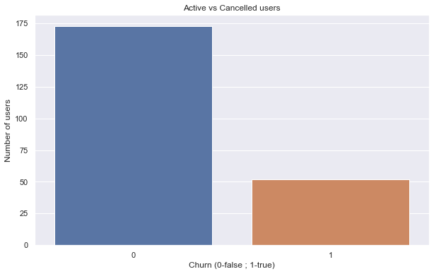

```python
plt.figure(figsize=(10, 6))
sns.set(style="darkgrid")
ax = sns.barplot(x="churn", y="count", data=data)
ax.set_title("Active vs Cancelled users")
ax.set_xlabel("Churn (0-false ; 1-true)")
ax.set_ylabel("Number of users")
```

> There are a total of 225 distinct users in this data set, 173 of which are active users and 52 have churned.

**Type of interactions** - `page`

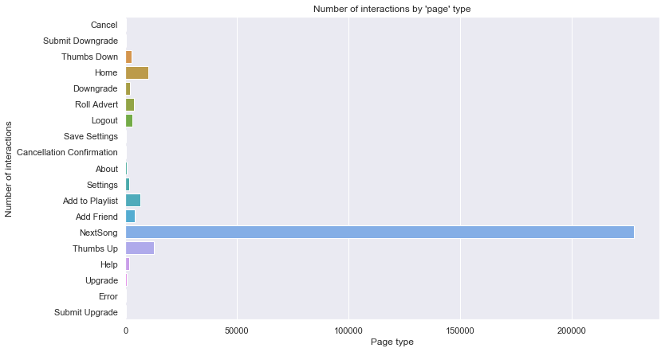

```python
# Checking type of interactions
data = df.groupby("page").count().alias("count").toPandas()
plt.figure(figsize=(12, 7))
sns.set(style="darkgrid")
ax = sns.barplot(x="count", y="page", data=data)
ax.set_title("Number of interactions by 'page' type")
ax.set_xlabel("Page type")
ax.set_ylabel("Number of interactions")
```

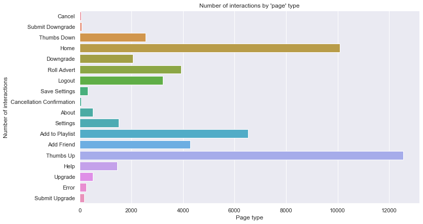

```python
# Checking type of interactions - excluding 'NextSong'
plt.figure(figsize=(12, 7))
sns.set(style="darkgrid")
ax = sns.barplot(x="count", y="page", data=data[data.page!='NextSong'])
ax.set_title("Number of interactions by 'page' type")
ax.set_xlabel("Page type")
ax.set_ylabel("Number of interactions")
```

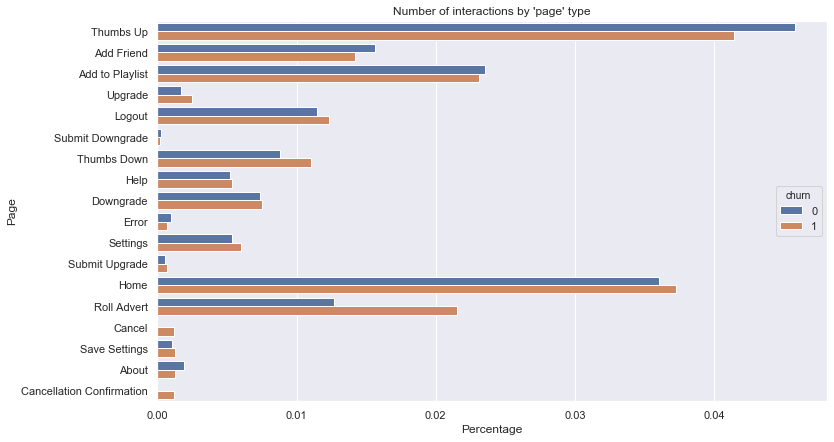

```python
# Interactions by churn type (percentage)
data = df.groupby("churn","page").count().alias("count").toPandas()

# Churned users
data_churned = data[data['churn']==1]
data_churned['count']=data_churned['count']/data_churned['count'].sum()

# Users who didn't churn
data_notchurned = data[data['churn']==0]
data_notchurned['count']=data_notchurned['count']/data_notchurned['count'].sum()

# Data append
data = data_churned.append(data_notchurned, sort=False)

# Ploting
plt.figure(figsize=(12, 7))
sns.set(style="darkgrid")
ax = sns.barplot(x="count", y="page", data=data[data['page']!="NextSong"], hue="churn")
ax.set_title("Number of interactions by 'page' type")
ax.set_xlabel("Percentage")
ax.set_ylabel("Page")
```

**Distribution by Gender** - `gender`

```python
# Checking distribution by gender
data = df.select(["userId","gender","churn"]).dropDuplicates().groupby(["gender","churn"]).count().alias("count").toPandas()
```

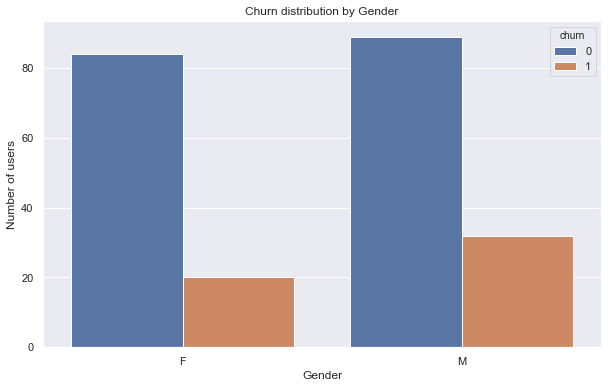

```python
# Ploting
plt.figure(figsize=(10, 6))
sns.set(style="darkgrid")
ax = sns.barplot(x="gender", y="count", hue="churn", data=data)
ax.set_title("Churn distribution by Gender")
ax.set_xlabel("Gender")
ax.set_ylabel("Number of users")
```

```python
# Dataframe with distribution by gender
data
```

|  | gender | churn | count |
| --- | --- | --- | --- |
| 0 | F | 0 | 84 |
| 1 | F | 1 | 20 |
| 2 | M | 0 | 89 |
| 3 | M | 1 | 32 |

```python
# Percentage of churn by gender
print ("-> Churn (%) Male:", 32/(89+32)*100)
print ("-> Churn (%) Female:", 20/(84+20)*100)
```

```
-> Churn (%) Male: 26.446280991735538
-> Churn (%) Female: 19.230769230769234
```

> More active males than females. This also applies to the users who churned (more males than females). Looking at the churn % by gender, we see there is a higher percentage for males (26.45%) than for females (19.23%).

**Distribution by Account type** - `level`

```python
# Checking distribution by gender
data = df.select(["userId","level","churn"]).dropDuplicates().groupby(["level","churn"]).count().alias("count").toPandas()
```

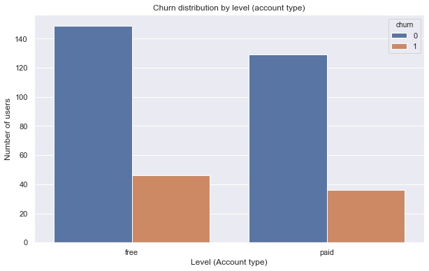

```python
# Ploting
plt.figure(figsize=(10, 6))
sns.set(style="darkgrid")
ax = sns.barplot(x="level", y="count", hue="churn", data=data)
ax.set_title("Churn distribution by level (account type)")
ax.set_xlabel("Level (Account type)")
ax.set_ylabel("Number of users")
```

```python
# Dataframe with distribution by level
data
```

|  | level | churn | count |
| --- | --- | --- | --- |
| 0 | free | 0 | 149 |
| 1 | paid | 0 | 129 |
| 2 | free | 1 | 46 |
| 3 | paid | 1 | 36 |

```python
# Percentage of churn by level (account type)
print ("-> Churn (%) free:", 149/(149+46)*100)
print ("-> Churn (%) paid:", 129/(129+36)*100)
```

```
-> Churn (%) free: 76.41025641025641
-> Churn (%) paid: 78.18181818181819
```

> Overall there are more free users than paid users. Regarding users who have churned, there is no significant differences between these two account types, it seems account type is not influencing churn rate.

**Distribution by location** - `location`

```python
# Checking distribution by gender
data = df.select(["userId","location","churn"]).dropDuplicates().groupby(["location","churn"]).count().alias("count").toPandas()
```

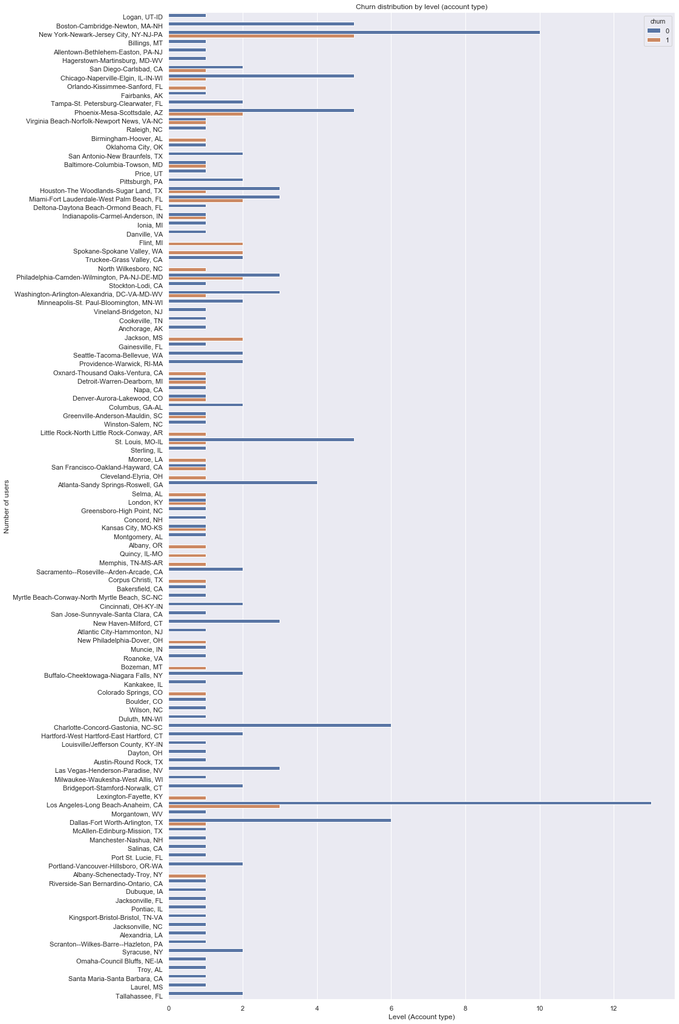

```python
# Ploting
plt.figure(figsize=(15, 30))
sns.set(style="darkgrid")
ax = sns.barplot(x="count", y="location", hue="churn", data=data,orient='h')
ax.set_title("Churn distribution by level (account type)")
ax.set_xlabel("Level (Account type)")
ax.set_ylabel("Number of users")
```

**Average interactions per sessionsId** - `sessionId`

```python
# Number of interactions per sessionId - by churn type
data = df.groupby("churn", "userId", "sessionId").count().toPandas()
```

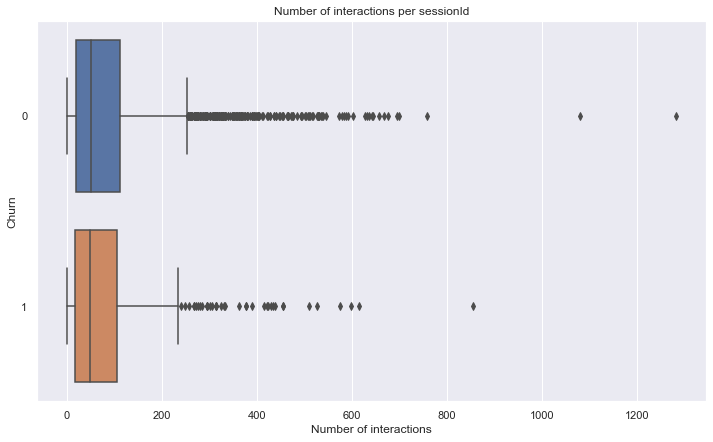

```python
# Ploting
plt.figure(figsize=(12, 7))
sns.set(style="darkgrid")
ax = sns.boxplot(x='count', y='churn', orient="h", data=data)
ax.set_title("Number of interactions per sessionId")
ax.set_xlabel("Number of interactions")
ax.set_ylabel("Churn")
```

> No significant differences between user who churned and those who didn't (similar number of interactions per sessionId).

**Number of 'Thumbs up' per sessionId** - `page` = 'Thumbs Up'

```python
# Number of interactions - thumbs up per sessionId - by churn type
data = df.filter(df['page'] == 'Thumbs Up').groupby("userId", "churn", "sessionId").count().toPandas()
```

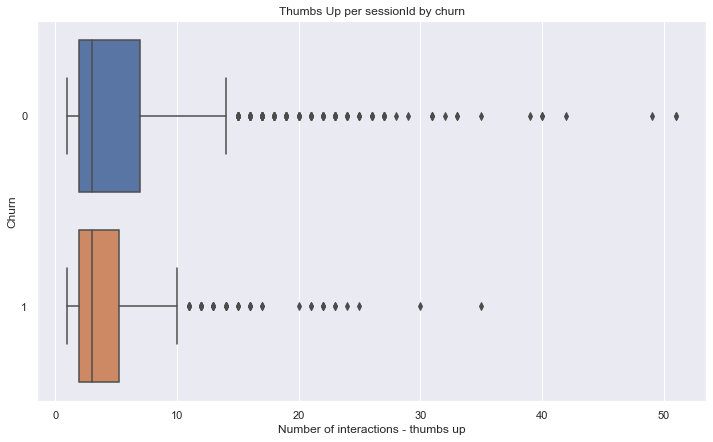

```python
# Ploting
plt.figure(figsize=(12, 7))
sns.set(style="darkgrid")
ax = sns.boxplot(x='count', y='churn', orient="h", data=data)
ax.set_title("Thumbs Up per sessionId by churn")
ax.set_xlabel("Number of interactions - thumbs up")
ax.set_ylabel("Churn")
```

**Number of 'Next Song' per sessionId** - `page` = 'Next Song'

```python
# Number of interactions - next song per sessionId - by churn type
data = df.filter(df['page'] == 'NextSong').groupby("userId", "churn", "sessionId").count().toPandas()
```

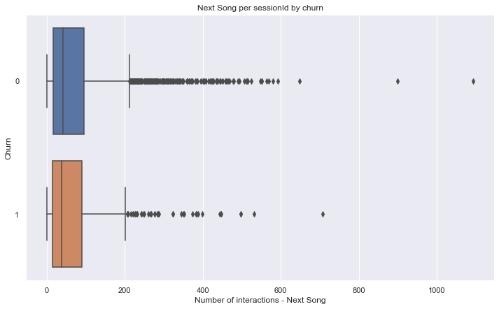

```python
# Ploting
plt.figure(figsize=(12, 7))
sns.set(style="darkgrid")
ax = sns.boxplot(x='count', y='churn', orient="h", data=data)
ax.set_title("Next Song per sessionId by churn")
ax.set_xlabel("Number of interactions - Next Song")
ax.set_ylabel("Churn")
```

> No significant differences between user who churned and those who didn't (similar number of interactions per sessionId).

**Evolution over time**

```python
'''
PySpark

# Adding Hour, day and weekday to dataframe
hour_extract = udf(lambda x: datetime.datetime.fromtimestamp(x / 1000.0).hour)
day_extract = udf(lambda x: datetime.datetime.fromtimestamp(x / 1000.0).day)
weekday_extract = udf(lambda x: datetime.datetime.fromtimestamp(x / 1000.0).strftime("%w"))

# Hour
df = df.withColumn("hour", hour_extract(df.ts))

# Day
df = df.withColumn("day", day_extract(df.ts))

# WeekDay
df = df.withColumn("weekday", weekday_extract(df.ts))

# Day registration
df = df.withColumn("reg_day", day_extract(df.registration))
'''
```

```
' \nPySpark\n\n# Adding Hour, day and weekday to dataframe\nhour_extract = udf(lambda x: datetime.datetime.fromtimestamp(x / 1000.0).hour)\nday_extract = udf(lambda x: datetime.datetime.fromtimestamp(x / 1000.0).day)\nweekday_extract = udf(lambda x: datetime.datetime.fromtimestamp(x / 1000.0).strfti…
```

```python
# Converting to pandas dataframe for convenience
df_pandas = df.toPandas()
```

```python
df_pandas.head(5)
```

|  | artist | auth | firstName | gender | itemInSession | lastName | length | level | location | method | page | registration | sessionId | song | status | ts | userAgent | userId | churn | downgrade |
| --- | --- | --- | --- | --- | --- | --- | --- | --- | --- | --- | --- | --- | --- | --- | --- | --- | --- | --- | --- | --- |
| 0 | Sleeping With Sirens | Logged In | Darianna | F | 0 | Carpenter | 202.97098 | free | Bridgeport-Stamford-Norwalk, CT | PUT | NextSong | 1538016340000 | 31 | Captain Tyin Knots VS Mr Walkway (No Way) | 200 | 1539003534000 | "Mozilla/5.0 (iPhone; CPU iPhone OS 7_1_2 like... | 100010 | 0 | 0 |
| 1 | Francesca Battistelli | Logged In | Darianna | F | 1 | Carpenter | 196.54485 | free | Bridgeport-Stamford-Norwalk, CT | PUT | NextSong | 1538016340000 | 31 | Beautiful_ Beautiful (Album) | 200 | 1539003736000 | "Mozilla/5.0 (iPhone; CPU iPhone OS 7_1_2 like... | 100010 | 0 | 0 |
| 2 | Brutha | Logged In | Darianna | F | 2 | Carpenter | 263.13098 | free | Bridgeport-Stamford-Norwalk, CT | PUT | NextSong | 1538016340000 | 31 | She's Gone | 200 | 1539003932000 | "Mozilla/5.0 (iPhone; CPU iPhone OS 7_1_2 like... | 100010 | 0 | 0 |
| 3 | None | Logged In | Darianna | F | 3 | Carpenter | NaN | free | Bridgeport-Stamford-Norwalk, CT | PUT | Thumbs Up | 1538016340000 | 31 | None | 307 | 1539003933000 | "Mozilla/5.0 (iPhone; CPU iPhone OS 7_1_2 like... | 100010 | 0 | 0 |
| 4 | Josh Ritter | Logged In | Darianna | F | 4 | Carpenter | 316.23791 | free | Bridgeport-Stamford-Norwalk, CT | PUT | NextSong | 1538016340000 | 31 | Folk Bloodbath | 200 | 1539004195000 | "Mozilla/5.0 (iPhone; CPU iPhone OS 7_1_2 like... | 100010 | 0 | 0 |

```python
# Adding columns with hour, day, weekday and day of registration
df_pandas['hour'] = df_pandas['ts'].apply(lambda row: datetime.datetime.fromtimestamp(row / 1000.0).hour)
df_pandas['day'] = df_pandas['ts'].apply(lambda row: datetime.datetime.fromtimestamp(row / 1000.0).day)
df_pandas['weekday'] = df_pandas['ts'].apply(lambda row: datetime.datetime.fromtimestamp(row / 1000.0).strftime("%w"))
```

```python
df_pandas.head(200)
```

[output not shown]

200 rows × 23 columns

*Average number of days until cancellation*

```python
# Filtering by cancellation events
df_pandas_cancel = df_pandas[df_pandas['page']=='Cancellation Confirmation']
df_pandas_cancel=df_pandas_cancel[["ts","registration"]]
df_pandas_cancel['ts']=df_pandas_cancel['ts'].apply(lambda row: datetime.datetime.fromtimestamp(row / 1000.0))
df_pandas_cancel['registration']= df_pandas_cancel['registration'].apply(lambda row: datetime.datetime.fromtimestamp(row / 1000.0))

df_pandas_cancel['diff_days'] = df_pandas_cancel['ts'] - df_pandas_cancel['registration']
df_pandas_cancel['diff_days']= df_pandas_cancel['diff_days']/np.timedelta64(1,'D')
#df_pandas_cancel['reg_day'] = df_pandas_cancel['registration'].apply(lambda row: datetime.datetime.fromtimestamp(row / 1000.0))
#df_pandas_cancel['cancel_day'] = df_pandas_cancel['ts'].apply(lambda row: datetime.datetime.fromtimestamp(row / 1000.0))
#df_pandas_cancel['days_until_cancel']=datetime.datetime(df_pandas_cancel['cancel_day']-df_pandas_cancel['reg_day']).days
```

```python
df_pandas_cancel.head(5)
```

|  | ts | registration | diff_days |
| --- | --- | --- | --- |
| 865 | 2018-10-12 05:35:18 | 2018-08-01 21:58:59 | 71.316887 |
| 8154 | 2018-10-17 08:39:32 | 2018-09-27 21:43:07 | 19.455845 |
| 14070 | 2018-11-12 19:40:08 | 2018-07-25 02:37:42 | 110.710023 |
| 15382 | 2018-11-20 19:04:09 | 2018-08-27 18:04:03 | 85.041736 |
| 19953 | 2018-10-16 23:30:37 | 2018-08-24 00:19:40 | 53.965938 |

```python
# Average days until cancellation
print("-> Average days until cancellation:", df_pandas_cancel["diff_days"].mean())
```

```
-> Average days until cancellation: 57.28756343482909
```

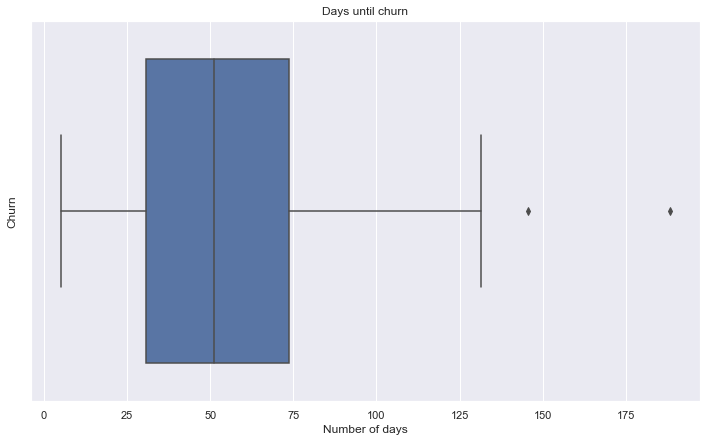

```python
# Ploting
plt.figure(figsize=(12, 7))
sns.set(style="darkgrid")
ax = sns.boxplot(y='diff_days', orient="h", data=df_pandas_cancel)
ax.set_title("Days until churn")
ax.set_xlabel("Number of days")
ax.set_ylabel("Churn")
```

*Cancellation events* by day of month

```python
# Page = Cancellation Confirmation - grouping by day
data = df_pandas[df_pandas['page']=='Cancellation Confirmation'][["day","page"]].groupby(["day"]).count()
```

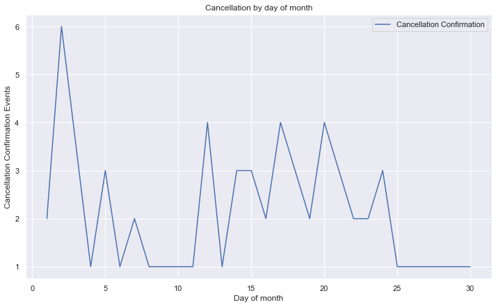

```python
# Ploting
plt.figure(figsize=(12, 7))
sns.set(style="darkgrid")
ax = sns.lineplot(data=data)
ax.legend(labels=["Cancellation Confirmation"])
ax.set_title("Cancellation by day of month")
ax.set_xlabel("Day of month")
ax.set_ylabel("Cancellation Confirmation Events")
```

> The 2nd day of the month is the day with the most Cancellation Confirmation events (max = 6).

*Cancellation events* by weekday

```python
# Page = Cancellation Confirmation - grouping by day
data = df_pandas[df_pandas['page']=='Cancellation Confirmation'][["weekday","page"]].groupby(["weekday"]).count()
```

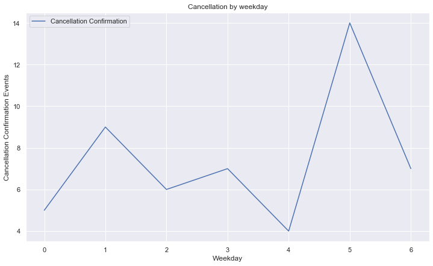

```python
# Ploting
plt.figure(figsize=(12, 7))
sns.set(style="darkgrid")
ax = sns.lineplot(data=data)
ax.legend(labels=["Cancellation Confirmation"])
ax.set_title("Cancellation by weekday")
ax.set_xlabel("Weekday")
ax.set_ylabel("Cancellation Confirmation Events")
```

> The weekday with the most Cancellation Confirmation events is Friday (weekday = 5), with a total of 14 Cancellations.

*Interactions over time by churn type*

```python
# Hourly
data = df_pandas[["hour","churn","page"]].groupby(["hour","churn"]).count().reset_index()
```

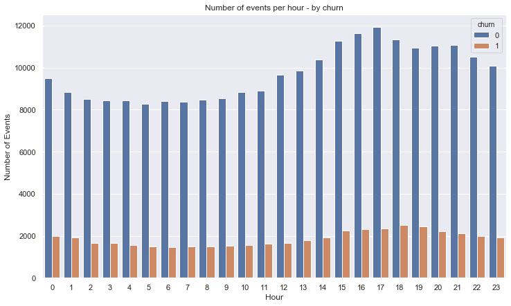

```python
# Ploting
plt.figure(figsize=(12, 7))
sns.set(style="darkgrid")
ax = sns.barplot(x="hour", y="page", hue="churn",data=data)
ax.set_title("Number of events per hour - by churn")
ax.set_xlabel("Hour")
ax.set_ylabel("Number of Events")
```

```python
# Weekday
data = df_pandas[["weekday","churn","page"]].groupby(["weekday","churn"]).count().reset_index()
```

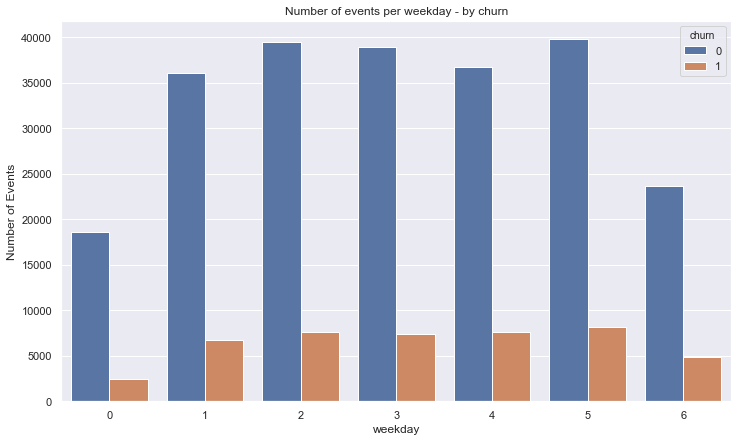

```python
# Ploting
plt.figure(figsize=(12, 7))
sns.set(style="darkgrid")
ax = sns.barplot(x="weekday", y="page", hue="churn",data=data)
ax.set_title("Number of events per weekday - by churn")
ax.set_xlabel("weekday")
ax.set_ylabel("Number of Events")
```

> Usage pattern is similar for both type of users (those who churn and those who don't).

# 5. Feature Engineering

Once you've familiarized yourself with the data, build out the features you find promising to train your model on. To work with the full dataset, you can follow the following steps.

- Write a script to extract the necessary features from the smaller subset of data
- Ensure that your script is scalable, using the best practices discussed in Lesson 3
- Try your script on the full data set, debugging your script if necessary

If you are working in the classroom workspace, you can just extract features based on the small subset of data contained here. Be sure to transfer over this work to the larger dataset when you work on your Spark cluster.

#### Extracting features

1. Number of songs played by user
2. Number of thumbs up
3. Number of thumbs down
4. Number of friends added
5. Number of songs added to playlist
6. Number of downgrades
7. Average number of songs per session
8. Number of distinct artist the user has listened to
9. Number of sessions
10. Average session duration
11. User lifetime
12. Categorical Features
    1. Gender
    2. Account type (free/paid) (most recent)
    3. Churn

```python
# Sanity check
df.agg(countDistinct(col("userId")).alias("# UserIds")).show()
```

```
+---------+
|# UserIds|
+---------+
|      225|
+---------+
```

```python
# Number of songs
feature_nsongs = df.filter(df['song']!='null').select('userID','song').groupBy('userID').count().withColumnRenamed('count', 'totalsongs').sort(col("count").desc())
feature_nsongs.show(5)
```

```
+------+----------+
|userID|totalsongs|
+------+----------+
|    39|      8002|
|    92|      5945|
|   140|      5664|
|300011|      4619|
|   124|      4079|
+------+----------+
only showing top 5 rows
```

```python
# Number of Thumbs Up
feature_thumbsup = df.filter(df['page']=='Thumbs Up').select('userID','page').groupBy('userID').count().withColumnRenamed('count', 'totalthumbsup').sort(col("count").desc())
feature_thumbsup.show(5)
```

```
+------+-------------+
|userID|totalthumbsup|
+------+-------------+
|300011|          437|
|    39|          388|
|300021|          336|
|300017|          303|
|    92|          292|
+------+-------------+
only showing top 5 rows
```

```python
# Number of Thumbs Down
feature_thumbsdown = df.filter(df['page']=='Thumbs Down').select('userID','page').groupBy('userID').count().withColumnRenamed('count', 'totalthumbsdown').sort(col("count").desc())
feature_thumbsdown.show(5)
```

```
+------+---------------+
|userID|totalthumbsdown|
+------+---------------+
|   140|             75|
|200023|             73|
|    92|             72|
|    39|             69|
|200004|             54|
+------+---------------+
only showing top 5 rows
```

```python
# Number of friends added
feature_addfriend = df.filter(df['page']=='Add Friend').select('userID','page').groupBy('userID').count().withColumnRenamed('count', 'friendsadded').sort(col("count").desc())
feature_addfriend.show(5)
```

```
+------+------------+
|userID|friendsadded|
+------+------------+
|   140|         143|
|    39|         122|
|    92|         110|
|300011|          93|
|300021|          89|
+------+------------+
only showing top 5 rows
```

```python
# Number of songs added to playlist
feature_addplist = df.filter(df['page']=='Add to Playlist').select('userID','page').groupBy('userID').count().withColumnRenamed('count', 'songsadded').sort(col("count").desc())
feature_addplist.show(5)
```

```
+------+----------+
|userID|songsadded|
+------+----------+
|    39|       240|
|    92|       181|
|   140|       148|
|300011|       146|
|   124|       118|
+------+----------+
only showing top 5 rows
```

```python
# Number of downgrades
feature_downgrade = df.filter(df['page']=='Submit Downgrade').select('userID','page').groupBy('userID').count().withColumnRenamed('count', 'downgrades').sort(col("count").desc())
feature_downgrade.show(5)
```

```
+------+----------+
|userID|downgrades|
+------+----------+
|   140|         3|
|    39|         3|
|    61|         2|
|    85|         2|
|200003|         2|
+------+----------+
only showing top 5 rows
```

```python
# Average number of songs per session
feature_songssession = df.filter(df.page=="NextSong").groupby("userId", "sessionId").count()
feature_songssession = feature_songssession.groupby("userId").agg(avg(feature_songssession["count"]).alias("avgSongPerSession")).sort("userId")
feature_songssession.show(5)
```

```
+------+------------------+
|userId| avgSongPerSession|
+------+------------------+
|    10|112.16666666666667|
|   100| 78.88235294117646|
|100001|             33.25|
|100002|             48.75|
|100003|              25.5|
+------+------------------+
only showing top 5 rows
```

```python
# Number of distinct artist the user has listened to
feature_artists = df.select("userId", "artist").dropDuplicates().groupby("userId").count().withColumnRenamed('count', 'artists').sort(col("count").desc())
feature_artists.show(5)
```

```
+------+-------+
|userId|artists|
+------+-------+
|    39|   3545|
|    92|   2905|
|   140|   2820|
|300011|   2492|
|   124|   2233|
+------+-------+
only showing top 5 rows
```

```python
# Number of sessions
feature_sessions = df.select("userId", "sessionId").dropDuplicates().groupby("userId").count().withColumnRenamed('count', 'sessions').sort(col("count").desc())
feature_sessions.show(5)
```

```
+------+--------+
|userId|sessions|
+------+--------+
|    39|     107|
|    92|      86|
|200023|      76|
|300011|      76|
|   140|      71|
+------+--------+
only showing top 5 rows
```

```python
# Average session duration
session_maxtime = df.groupBy('userId', 'sessionId').max('ts').withColumnRenamed('max(ts)', 'end')
session_mintime = df.groupBy('userId', 'sessionId').min('ts').withColumnRenamed('min(ts)', 'start')
session_duration = session_mintime.join(session_maxtime,['userId', 'sessionId'])
session_duration = session_duration.select('userId', 'sessionId', ((session_duration.end-session_duration.start)/(1000*60)).alias('session_duration_min'))

# computing average
feature_avg_session_user = session_duration.groupBy('userId').agg(avg('session_duration_min').alias('avg_session_duration')).sort(col("avg_session_duration").desc())
feature_avg_session_user = feature_avg_session_user.na.fill(0)
feature_avg_session_user.show(5)
```

```
+------+--------------------+
|userId|avg_session_duration|
+------+--------------------+
|    91|              1179.9|
|    19|   904.8666666666667|
|    51|   872.3566666666666|
|   101|   817.5800000000002|
|    62|   816.8979166666667|
+------+--------------------+
only showing top 5 rows
```

```python
# User lifetime
# Time since registration
max_time_user = df.groupby("userId").max("ts").sort("userId")
reg_time_user = df.select("userId", "registration").dropDuplicates().sort("userId")
feature_user_lifetime = reg_time_user.join(max_time_user, reg_time_user.userId == max_time_user.userId).select(reg_time_user["userId"], ((max_time_user["max(ts)"]-reg_time_user["registration"])/(1000*60)).alias("lifetime_minutes")).sort(col("lifetime_minutes").desc())
feature_user_lifetime.show(5)
```

```
+------+------------------+
|userId|  lifetime_minutes|
+------+------------------+
|     6|         369183.85|
|   119|         271957.35|
|300001| 271168.9666666667|
|100004|248313.71666666667|
|300015|246934.13333333333|
+------+------------------+
only showing top 5 rows
```

```python
# Categorical Feature - Gender
feature_gender = df.select("userId", "gender").dropDuplicates().replace(["F", "M"], ["0", "1"], "Gender").select('userId', col('gender').cast('int'))
feature_gender.show(5)
```

```
+------+------+
|userId|gender|
+------+------+
|    44|     0|
|    46|     0|
|    41|     0|
|    72|     0|
|300023|     0|
+------+------+
only showing top 5 rows
```

```python
# Categorical Feature - Account type (level)
max_time_user = df.groupby("userId").max("ts").withColumnRenamed('max(ts)', 'ts').sort("userId")
most_recent_level = df.select("userId", "level","ts").dropDuplicates().sort("userId")
cond = [most_recent_level.userId == max_time_user.userId, most_recent_level.ts == max_time_user.ts]
feature_level = most_recent_level.join(max_time_user, cond).select(max_time_user.userId,most_recent_level.level)
feature_level = feature_level.select("userId","level")
feature_level = feature_level.replace(["free", "paid"], ["0", "1"], "level")
feature_level.show(5)
```

```
+------+-----+
|userId|level|
+------+-----+
|200008|    1|
|    96|    1|
|200002|    1|
|    49|    1|
|    68|    0|
+------+-----+
only showing top 5 rows
```

```python
# Categorical Feature - Churn
feature_target = df.select('userId', col('churn').alias('target_churn')).dropDuplicates()
feature_target.show(5)
```

```
+------+------------+
|userId|target_churn|
+------+------------+
|100010|           0|
|200002|           0|
|   125|           1|
|   124|           0|
|    51|           1|
+------+------------+
only showing top 5 rows
```

#### Putting it all together

```python
def feature_engineering(df):
    '''
    Extracting features from the original dataframe.
    These features will then be used by the ML algorithm to predict churn.


    Inputs
        dataframe (pyspark dataframe) - original dataset (whith churn already defined - new column 'churn')

    Outputs
        data - new dataframe with all the features extracted/computed from the original dataset
    '''

    print("-> Starting Feature Engineering...")
    start = datetime.datetime.now()

    # Number of songs
    print("* Number of songs")
    feature_nsongs = df.filter(df['song']!='null').select('userID','song').groupBy('userID').count().withColumnRenamed('count', 'totalsongs').sort(col("count").desc())

    # Number of Thumbs Up
    print("* Number of Thumbs Up")
    feature_thumbsup = df.filter(df['page']=='Thumbs Up').select('userID','page').groupBy('userID').count().withColumnRenamed('count', 'totalthumbsup').sort(col("count").desc())

    # Number of Thumbs Down
    print("* Number of Thumbs Down")
    feature_thumbsdown = df.filter(df['page']=='Thumbs Down').select('userID','page').groupBy('userID').count().withColumnRenamed('count', 'totalthumbsdown').sort(col("count").desc())

    # Number of friends added
    print("* Number of friends added")
    feature_addfriend = df.filter(df['page']=='Add Friend').select('userID','page').groupBy('userID').count().withColumnRenamed('count', 'friendsadded').sort(col("count").desc())

    # Number of songs added to playlist
    print("* Number of songs added to playlist")
    feature_addplist = df.filter(df['page']=='Add to Playlist').select('userID','page').groupBy('userID').count().withColumnRenamed('count', 'songsadded').sort(col("count").desc())

    # Number of downgrades
    print("* Number of downgrades")
    feature_downgrade = df.filter(df['page']=='Submit Downgrade').select('userID','page').groupBy('userID').count().withColumnRenamed('count', 'downgrades').sort(col("count").desc())

    # Average number of songs per session
    print("* Number of songs per session")
    feature_songssession = df.filter(df.page=="NextSong").groupby("userId", "sessionId").count()
    feature_songssession = feature_songssession.groupby("userId").agg(avg(feature_songssession["count"]).alias("avgSongPerSession")).sort("userId")

    # Number of distinct artist the user has listened to
    print("* Number of distinct artist the user has listened to")
    feature_artists = df.select("userId", "artist").dropDuplicates().groupby("userId").count().withColumnRenamed('count', 'artists').sort(col("count").desc())

    # Number of sessions
    print("* Number of sessions")
    feature_sessions = df.select("userId", "sessionId").dropDuplicates().groupby("userId").count().withColumnRenamed('count', 'sessions').sort(col("count").desc())

    # Average session duration
    print("* Average session duration")
    session_maxtime = df.groupBy('userId', 'sessionId').max('ts').withColumnRenamed('max(ts)', 'end')
    session_mintime = df.groupBy('userId', 'sessionId').min('ts').withColumnRenamed('min(ts)', 'start')
    session_duration = session_mintime.join(session_maxtime,['userId', 'sessionId'])
    session_duration = session_duration.select('userId', 'sessionId', ((session_duration.end-session_duration.start)/(1000*60)).alias('session_duration_min'))
    # computing average
    feature_avg_session_user = session_duration.groupBy('userId').agg(avg('session_duration_min').alias('avg_session_duration')).sort(col("avg_session_duration").desc())
    feature_avg_session_user = feature_avg_session_user.na.fill(0)

    # User lifetime
    print("* User lifetime")
    max_time_user = df.groupby("userId").max("ts").sort("userId")
    reg_time_user = df.select("userId", "registration").dropDuplicates().sort("userId")
    feature_user_lifetime = reg_time_user.join(max_time_user, reg_time_user.userId == max_time_user.userId).select(reg_time_user["userId"], ((max_time_user["max(ts)"]-reg_time_user["registration"])/(1000*60)).alias("lifetime_minutes")).sort(col("lifetime_minutes").desc())

    # Categorical Feature - Gender
    print("* Categorical Feature - Gender")
    feature_gender = df.select("userId", "gender").dropDuplicates().replace(["F", "M"], ["0", "1"], "Gender").select('userId', col('gender').cast('int'))

    # Categorical Feature - Account type (level)
    print("* Categorical Feature - Account type (level)")
    max_time_user = df.groupby("userId").max("ts").withColumnRenamed('max(ts)', 'ts').sort("userId")
    most_recent_level = df.select("userId", "level","ts").dropDuplicates().sort("userId")
    cond = [most_recent_level.userId == max_time_user.userId, most_recent_level.ts == max_time_user.ts]
    feature_level = most_recent_level.join(max_time_user, cond).select(max_time_user.userId,most_recent_level.level)
    feature_level = feature_level.select("userId","level")
    feature_level = feature_level.replace(["free", "paid"], ["0", "1"], "level")

    # Categorical Feature - Churn
    print("* Categorical Feature - Churn (target feature)")
    feature_target = df.select('userId', col('churn').alias('target_churn')).dropDuplicates()

    # Joining all features
    data = feature_gender.join(feature_nsongs,'userID','outer') \
    .join(feature_thumbsdown,'userID','outer') \
    .join(feature_addfriend,'userID','outer') \
    .join(feature_addplist,'userID','outer') \
    .join(feature_downgrade,'userID','outer') \
    .join(feature_songssession,'userID','outer') \
    .join(feature_artists,'userID','outer') \
    .join(feature_sessions,'userID','outer') \
    .join(feature_avg_session_user,'userID','outer') \
    .join(feature_user_lifetime,'userID','outer') \
    .join(feature_thumbsup,'userID','outer') \
    .join(feature_level,'userID','outer') \
    .join(feature_target,'userID','outer') \
    .drop('userID') \
    .fillna(0)


    print ("-> Final dataframe with:",data.count(), "rows and ",len(data.dtypes),"columns")
    print ("-> Duration:",datetime.datetime.now()-start,"s")
    print ("-> Process finished")

    return data
```

```python
# Feature Engineering
data_final = feature_engineering(df)
```

```
-> Starting Feature Engineering...
* Number of songs
* Number of Thumbs Up
* Number of Thumbs Down
* Number of friends added
* Number of songs added to playlist
* Number of downgrades
* Number of songs per session
* Number of distinct artist the user has listened to
* Number of sessions
* Average session duration
* User lifetime
* Categorical Feature - Gender
* Categorical Feature - Account type (level)
* Categorical Feature - Churn (target feature)
-> Final dataframe with: 225 rows and  14 columns
-> Duration: 0:05:51.697727 s
-> Process finished
```

```python
# Converting to pandas
#data_final_pd = data_final.toPandas()
# Saving final data set
#data_final_pd.to_csv('data_final.csv')
```

```python
# Saving final data set
data_final.write.csv('data_final_spark.csv', header = True)
```

# 6. Modeling

Split the full dataset into train, test, and validation sets. Test out several of the machine learning methods you learned. Evaluate the accuracy of the various models, tuning parameters as necessary. Determine your winning model based on test accuracy and report results on the validation set. Since the churned users are a fairly small subset, I suggest using F1 score as the metric to optimize.

#### 6.A) Loading Data

```python
# Loading Data
data_final = spark_session.read.csv('data_final_spark.csv', header = True)
```

```python
# Top rows - sanity check
# Converting to pandas dataframe for better visualization (limiting to 10 rows for low memory usage)
df_pandas = data_final.limit(10).toPandas()
df_pandas
```

|  | gender | totalsongs | totalthumbsdown | friendsadded | songsadded | downgrades | avgSongPerSession | artists | sessions | avg_session_duration | lifetime_minutes | totalthumbsup | level | target_churn |
| --- | --- | --- | --- | --- | --- | --- | --- | --- | --- | --- | --- | --- | --- | --- |
| 0 | 0 | 942 | 11 | 19 | 23 | 2 | 47.1 | 734 | 21 | 185.98650793650793 | 248313.71666666667 | 35 | 1 | 0 |
| 1 | 0 | 1781 | 17 | 23 | 43 | 0 | 68.5 | 1215 | 26 | 281.0339743589744 | 180839.1 | 84 | 1 | 0 |
| 2 | 1 | 1644 | 9 | 27 | 58 | 0 | 91.33333333333333 | 1138 | 18 | 380.71481481481476 | 102937.76666666666 | 84 | 1 | 0 |
| 3 | 0 | 29 | 0 | 7 | 0 | 0 | 14.5 | 30 | 2 | 63.74166666666667 | 144016.26666666666 | 2 | 0 | 0 |
| 4 | 1 | 37 | 0 | 0 | 0 | 0 | 9.25 | 38 | 5 | 29.70666666666667 | 146862.05 | 0 | 0 | 0 |
| 5 | 1 | 2577 | 21 | 33 | 72 | 0 | 88.86206896551724 | 1644 | 30 | 357.505 | 89417.8 | 135 | 1 | 0 |
| 6 | 1 | 1564 | 20 | 26 | 51 | 2 | 92.0 | 1101 | 19 | 340.22456140350874 | 174095.88333333333 | 72 | 0 | 0 |
| 7 | 0 | 5664 | 75 | 143 | 148 | 3 | 84.53731343283582 | 2820 | 71 | 328.06525821596244 | 116071.38333333333 | 277 | 1 | 0 |
| 8 | 0 | 927 | 13 | 12 | 30 | 0 | 132.42857142857142 | 742 | 7 | 601.25 | 18862.583333333332 | 40 | 1 | 1 |
| 9 | 0 | 1073 | 9 | 25 | 42 | 1 | 107.3 | 835 | 11 | 401.67121212121214 | 60670.583333333336 | 52 | 1 | 1 |

```python
# Dataset distribution by target
data_final.groupby("target_churn").count().show()
```

```
+------------+-----+
|target_churn|count|
+------------+-----+
|           0|  173|
|           1|   52|
+------------+-----+
```

```python
# data-types
data_final.printSchema()
```

```
root
 |-- gender: string (nullable = true)
 |-- totalsongs: string (nullable = true)
 |-- totalthumbsdown: string (nullable = true)
 |-- friendsadded: string (nullable = true)
 |-- songsadded: string (nullable = true)
 |-- downgrades: string (nullable = true)
 |-- avgSongPerSession: string (nullable = true)
 |-- artists: string (nullable = true)
 |-- sessions: string (nullable = true)
 |-- avg_session_duration: string (nullable = true)
 |-- lifetime_minutes: string (nullable = true)
 |-- totalthumbsup: string (nullable = true)
 |-- level: string (nullable = true)
 |-- target_churn: string (nullable = true)
```

```python
# Converting all data to numeric
features_list_int = ["gender","totalsongs","totalthumbsdown","friendsadded","songsadded","downgrades","artists","sessions","totalthumbsup","level","target_churn"]
features_list_float = ["avgSongPerSession","avg_session_duration","lifetime_minutes"]

# Converting to int
for col in features_list_int:
    data_final = data_final.withColumn(col, data_final[col].cast(IntegerType()))
# Converting to float
for col in features_list_float:
    data_final = data_final.withColumn(col, data_final[col].cast(FloatType()))
```

```python
# data-types
data_final.printSchema()
```

```
root
 |-- gender: integer (nullable = true)
 |-- totalsongs: integer (nullable = true)
 |-- totalthumbsdown: integer (nullable = true)
 |-- friendsadded: integer (nullable = true)
 |-- songsadded: integer (nullable = true)
 |-- downgrades: integer (nullable = true)
 |-- avgSongPerSession: float (nullable = true)
 |-- artists: integer (nullable = true)
 |-- sessions: integer (nullable = true)
 |-- avg_session_duration: float (nullable = true)
 |-- lifetime_minutes: float (nullable = true)
 |-- totalthumbsup: integer (nullable = true)
 |-- level: integer (nullable = true)
 |-- target_churn: integer (nullable = true)
```

```python
data_final.show(1)
```

```
+------+----------+---------------+------------+----------+----------+-----------------+-------+--------+--------------------+----------------+-------------+-----+------------+
|gender|totalsongs|totalthumbsdown|friendsadded|songsadded|downgrades|avgSongPerSession|artists|sessions|avg_session_duration|lifetime_minutes|totalthumbsup|level|target_churn|
+------+----------+---------------+------------+----------+----------+-----------------+-------+--------+--------------------+----------------+-------------+-----+------------+
|     0|       942|             11|          19|        23|         2|             47.1|    734|      21|           185.98651|       248313.72|           35|    1|           0|
+------+----------+---------------+------------+----------+----------+-----------------+-------+--------+--------------------+----------------+-------------+-----+------------+
only showing top 1 row
```

#### 6.B) Scaling and splitting

```python
# Vector assembler for input features
features = ["gender","totalsongs","totalthumbsdown","friendsadded","songsadded","downgrades","avgSongPerSession","artists","sessions","avg_session_duration","lifetime_minutes","totalthumbsup","level"]
assembler = VectorAssembler(inputCols=features, outputCol="NumFeatures")
data = assembler.transform(data_final)
```

```python
# Scaling data - standardize the features by taking off the mean and dividing by the standard deviation
scaler = StandardScaler(withMean=True, withStd=True, inputCol='NumFeatures', outputCol='scaled_features')
scaler_fit = scaler.fit(data)
scaled_data = scaler_fit.transform(data)
```

```python
# Putting it all together (scaled features and target label 'target_churn')
data = scaled_data.select(data.target_churn.alias('label'), scaled_data.scaled_features.alias('features'))
```

```python
data.show(25)
```

```
+-----+--------------------+
|label|            features|
+-----+--------------------+
|    0|[-1.0762390990345...|
|    0|[-1.0762390990345...|
|    0|[0.92503195288915...|
|    0|[-1.0762390990345...|
|    0|[0.92503195288915...|
|    0|[0.92503195288915...|
|    0|[0.92503195288915...|
|    0|[-1.0762390990345...|
|    1|[-1.0762390990345...|
|    1|[-1.0762390990345...|
|    0|[0.92503195288915...|
|    0|[0.92503195288915...|
|    0|[-1.0762390990345...|
|    0|[0.92503195288915...|
|    1|[0.92503195288915...|
|    0|[-1.0762390990345...|
|    0|[-1.0762390990345...|
|    0|[-1.0762390990345...|
|    1|[0.92503195288915...|
|    0|[0.92503195288915...|
|    0|[0.92503195288915...|
|    0|[-1.0762390990345...|
|    0|[-1.0762390990345...|
|    1|[0.92503195288915...|
|    0|[0.92503195288915...|
+-----+--------------------+
only showing top 25 rows
```

```python
# Train test split
train, test = data.randomSplit([0.8, 0.2], seed=42)
```

#### 6.C) Training (with hyperparameter tuning) and Predicting

Models were selected from the pyspark documentation: https://spark.apache.org/docs/latest/ml-classification-regression.html During training, all the hyperparameters are tunned using GridSearch for that

```python
def train_predict(train, test):
    '''
    This function will train several models on the train and test datasets previously built.
    All the models will be evaluated regarding accuracy, f-1 score and time it took to train, all the results will then be plotted.

    Inputs
        train - train dataset
        test - test dataset

    Outputs
        classifier - all the classifiers that were tested
        accuracy - accuracy score for all the classifiers
        f1score - f1 score for all the classifiers
        timetrain - the time it took for training for each one of the classifiers
        bestclass - best classifier based on f1 score
    '''

    # Auxiliar lists
    classifier = []
    accuracy = []
    f1score = []
    timetrain = []
    f1score_aux = 0
    f1score_aux2 = 0

    ### Training and predicting

    ## Random Forest Classifier
    start = datetime.datetime.now()
    model = RandomForestClassifier(labelCol="label", featuresCol="features")
    paramGrid = ParamGridBuilder().addGrid(model.maxDepth,[5, 10]).addGrid(model.impurity,['entropy', 'gini']).addGrid(model.numTrees ,[10, 20]).build()
    f1_eval = MulticlassClassificationEvaluator(metricName='f1')
    crossval = CrossValidator(estimator=model,estimatorParamMaps=paramGrid,evaluator=f1_eval,numFolds=3)

    rfmodel = crossval.fit(train)
    results = rfmodel.transform(test)
    evaluator = MulticlassClassificationEvaluator(predictionCol="prediction")

    # Saving results
    classifier.append("Random Forest Classifier")
    accuracy.append(evaluator.evaluate(results, {evaluator.metricName: "accuracy"}))
    f1score_aux = (evaluator.evaluate(results, {evaluator.metricName: "f1"}))
    f1score.append(f1score_aux)
    end = datetime.datetime.now()
    timetrain.append((end-start).total_seconds())
    bestclass = rfmodel


    ## Gradient Boosted Trees
    start = datetime.datetime.now()
    model = GBTClassifier(labelCol="label", featuresCol="features",maxIter=10,seed=42)
    paramGrid = ParamGridBuilder().addGrid(model.maxDepth,[2, 3, 5]).addGrid(model.maxIter ,[5, 10]).build()
    f1_eval = MulticlassClassificationEvaluator(metricName='f1')
    crossval = CrossValidator(estimator=model,estimatorParamMaps=paramGrid,evaluator=f1_eval,numFolds=3)

    gbtmodel = crossval.fit(train)
    results = gbtmodel.transform(test)
    evaluator = MulticlassClassificationEvaluator(predictionCol="prediction")

    # Saving results
    classifier.append("Gradient Boosted Trees")
    accuracy.append(evaluator.evaluate(results, {evaluator.metricName: "accuracy"}))
    f1score_aux2 = (evaluator.evaluate(results, {evaluator.metricName: "f1"}))
    f1score.append(f1score_aux2)
    end = datetime.datetime.now()
    timetrain.append((end-start).total_seconds())
    if f1score_aux2>f1score_aux:
        bestclass=gbtmodel
        f1score_aux=f1score_aux2


    ## Decision Tree Classifier
    start = datetime.datetime.now()
    model = DecisionTreeClassifier(labelCol="label", featuresCol="features",seed=42)
    paramGrid = ParamGridBuilder().addGrid(model.impurity,['entropy', 'gini']).addGrid(model.maxDepth,[2, 3, 4, 5, 8, 10, 15]).build()
    f1_eval = MulticlassClassificationEvaluator(metricName='f1')
    crossval = CrossValidator(estimator=model,estimatorParamMaps=paramGrid,evaluator=f1_eval,numFolds=3)

    dtmodel = crossval.fit(train)
    results = dtmodel.transform(test)
    evaluator = MulticlassClassificationEvaluator(predictionCol="prediction")

    # Saving results
    classifier.append("Decision Tree Classifier")
    accuracy.append(evaluator.evaluate(results, {evaluator.metricName: "accuracy"}))
    f1score_aux2 = (evaluator.evaluate(results, {evaluator.metricName: "f1"}))
    f1score.append(f1score_aux2)
    end = datetime.datetime.now()
    timetrain.append((end-start).total_seconds())
    if f1score_aux2>f1score_aux:
        bestclass=dtmodel
        f1score_aux=f1score_aux2


    ## Logistic Regression
    start = datetime.datetime.now()

    model = LogisticRegression(labelCol="label", featuresCol="features",maxIter=10)
    paramGrid = ParamGridBuilder().addGrid(model.elasticNetParam,[0.0, 0.1, 0.4, 1.0]).addGrid(model.regParam,[0.0, 0.05, 0.1]).build()
    f1_eval = MulticlassClassificationEvaluator(metricName='f1')
    crossval = CrossValidator(estimator=model,estimatorParamMaps=paramGrid,evaluator=f1_eval,numFolds=3)

    lrmodel = crossval.fit(train)
    results = lrmodel.transform(test)
    evaluator = MulticlassClassificationEvaluator(predictionCol="prediction")

    # Saving results
    classifier.append("Logistic Regression")
    accuracy.append(evaluator.evaluate(results, {evaluator.metricName: "accuracy"}))
    f1score_aux2 = (evaluator.evaluate(results, {evaluator.metricName: "f1"}))
    f1score.append(f1score_aux2)
    end = datetime.datetime.now()
    timetrain.append((end-start).total_seconds())
    if f1score_aux2>f1score_aux:
        bestclass=lrmodel
        f1score_aux=f1score_aux2


    ## LinearSVC
    start = datetime.datetime.now()

    model = LinearSVC(labelCol="label", featuresCol="features")
    paramGrid = ParamGridBuilder().addGrid(model.maxIter ,[5, 10]).addGrid(model.regParam ,[0.01, 0.05, 0.1]).build()
    f1_eval = MulticlassClassificationEvaluator(metricName='f1')
    crossval = CrossValidator(estimator=model,estimatorParamMaps=paramGrid,evaluator=f1_eval,numFolds=3)

    lsvcmodel = crossval.fit(train)
    results = lsvcmodel.transform(test)
    evaluator = MulticlassClassificationEvaluator(predictionCol="prediction")

    # Saving results
    classifier.append("Linear SVC")
    accuracy.append(evaluator.evaluate(results, {evaluator.metricName: "accuracy"}))
    f1score_aux2 = (evaluator.evaluate(results, {evaluator.metricName: "f1"}))
    f1score.append(f1score_aux2)
    end = datetime.datetime.now()
    timetrain.append((end-start).total_seconds())
    if f1score_aux2>f1score_aux:
        bestclass=lsvcmodel
        f1score_aux=f1score_aux2

    return classifier, accuracy, f1score, timetrain, bestclass;
```

```python
def print_scores(classifier, accuracy, f1score, timetrain):

    '''
    This function will plot the scores attained for each one of the classifiers.

    Inputs
        classifier - all the classifiers that were tested
        accuracy - accuracy score for all the classifiers
        f1score - f1 score for all the classifiers
        timetrain - the time it took for training for each one of the classifiers

    Outputs
        NA
    '''

    # Creating dataframe with metrics
    metrics = pd.DataFrame(columns=['classifier', 'accuracy', 'f1score','time'])
    metrics['classifier']=classifier
    metrics['accuracy']=accuracy
    metrics['f1score']=f1score
    metrics['time']=timetrain

    print(metrics)

    # Accuracy
    plt.figure(figsize=(12, 7))
    sns.set(style="darkgrid")
    ax = sns.barplot(x='classifier', y='accuracy', orient="v", data=metrics)
    ax.set_title("Accuracy by classifier")
    ax.set_xlabel("Classifier")
    ax.set_ylabel("Accuracy")
    ax.set_ylim(0, 1)
    for p in ax.patches:
        ax.annotate(format(p.get_height(), '.4f'), (p.get_x() + p.get_width() / 2., p.get_height()), ha = 'center', va = 'center', xytext = (0, 10), textcoords = 'offset points')

    # F1score
    plt.figure(figsize=(12, 7))
    sns.set(style="darkgrid")
    ax = sns.barplot(x='classifier', y='f1score', orient="v", data=metrics)
    ax.set_title("f1score by classifier")
    ax.set_xlabel("Classifier")
    ax.set_ylabel("f1score")
    ax.set_ylim(0, 1)
    for p in ax.patches:
        ax.annotate(format(p.get_height(), '.4f'), (p.get_x() + p.get_width() / 2., p.get_height()), ha = 'center', va = 'center', xytext = (0, 10), textcoords = 'offset points')


    # Time to train
    plt.figure(figsize=(12, 7))
    sns.set(style="darkgrid")
    ax = sns.barplot(x='classifier', y='time', orient="v", data=metrics)
    ax.set_title("Time to train by classifier")
    ax.set_xlabel("Classifier")
    ax.set_ylabel("Time to train [s]")
    for p in ax.patches:
        ax.annotate(format(p.get_height(), '.4f'), (p.get_x() + p.get_width() / 2., p.get_height()), ha = 'center', va = 'center', xytext = (0, 10), textcoords = 'offset points')


    return;
```

```python
# Training and predicting
classifier, accuracy, f1score, timetrain, bestclass = train_predict(train,test)
```

```
                 classifier  accuracy   f1score       time
0  Random Forest Classifier  0.777778  0.747710  50.091728
1    Gradient Boosted Trees  0.740741  0.690657  95.441571
2  Decision Tree Classifier  0.722222  0.702811  56.105295
3       Logistic Regression  0.759259  0.720124  63.920029
4                Linear SVC  0.722222  0.605735  47.068066
```

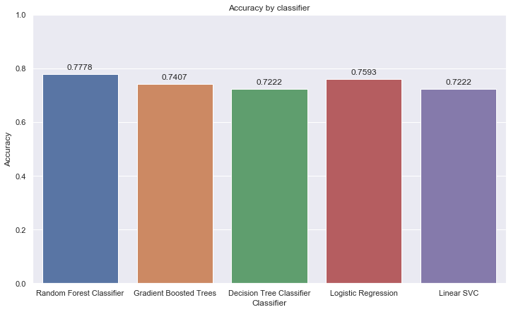

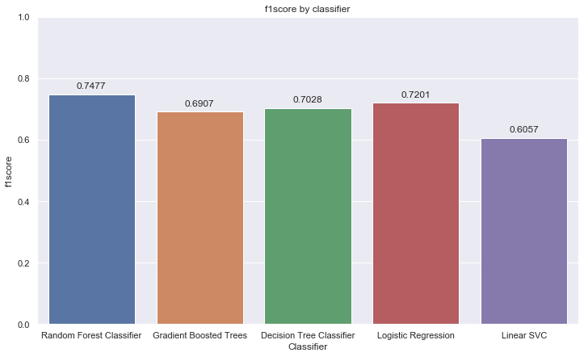

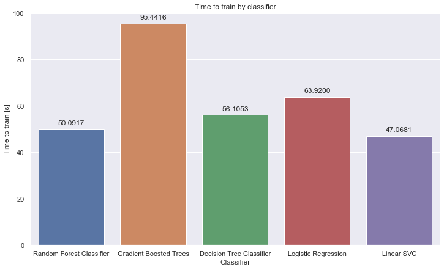

```python
# Pltoting scores
print_scores(classifier, accuracy, f1score, np.array(timetrain))
```

> From the results above, the model selected as the best one is **Random Forest Classifier** (with the best accuracy and f1score). Despite having really small training duration for all the classifiers, we should keep in mind this data set is really small. When working with larger datasets time efficiency is an important factor so it would be important to find the best score vs time to train.

#### 6.D) Final Result

```python
# Best Model & Parameters
model=bestclass.bestModel
print("-> Model:", model)
```

```
-> Model: RandomForestClassificationModel (uid=RandomForestClassifier_26a31d95c683) with 20 trees
```

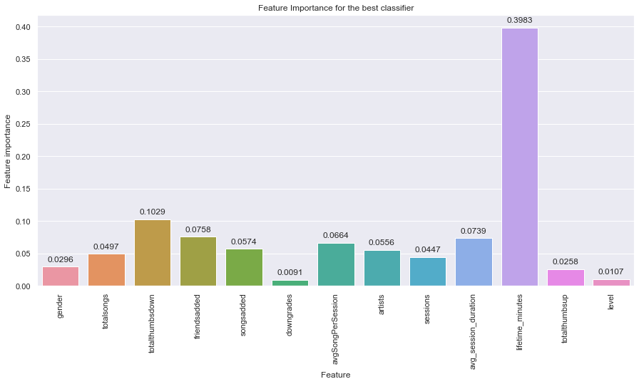

```python
# Feature Importance
feat_imp = model.featureImportances
features = ["gender","totalsongs","totalthumbsdown","friendsadded","songsadded","downgrades","avgSongPerSession","artists","sessions","avg_session_duration","lifetime_minutes","totalthumbsup","level"]
data_features = pd.DataFrame()
data_features['features']=features
data_features['feat_imp']=feat_imp

# Plot
plt.figure(figsize=(15, 7))
sns.set(style="darkgrid")
ax = sns.barplot(x='features', y='feat_imp', orient="v", data=data_features)
ax.set_title("Feature Importance for the best classifier")
ax.set_xlabel("Feature")
ax.set_ylabel("Feature importance")
ax.set_xticklabels(labels=data_features['features'],rotation=90)
for p in ax.patches:
        ax.annotate(format(p.get_height(), '.4f'), (p.get_x() + p.get_width() / 2., p.get_height()), ha = 'center', va = 'center', xytext = (0, 10), textcoords = 'offset points')
```

# 7. Conclusion

The end-to-end project was successfuly implemented in this workspace. All the data loading, processing, feature engineering and machine learning was done using Spark (PySpark).

For the churn prediction model, 13 new features were built (derived from the original dataset). Moreover, 5 classification models were trained on the training set (with crossvalidation) and the hyperparameters were tuned using Grid Search. The results attained were:

| Classifier | Accuracy | f1score | Time |
| --- | --- | --- | --- |
| Random Forest Classifier | 0.777778 | 0.747710 | 50.091728 |
| Gradient Boosted Trees | 0.740741 | 0.690657 | 95.441571 |
| Decision Tree Classifier | 0.722222 | 0.702811 | 56.105295 |
| Logistic Regression | 0.759259 | 0.720124 | 63.920029 |
| Linear SVC | 0.722222 | 0.605735 | 47.068066 |

The best classifier seems to be *Random Forest*, which achieved ~**78% accuracy** and **0,75 f1 Score**.

When looking at the feature importance, the *lifetime* stands out meaning it has a really important role in whether the user is prone to churn or not. The second most relevant feature is *Thumbs down* which might be easier to understand since higher number of thumbs down might indicate the user is not satisfied with the songs that are being suggested by the application. It seems that *number of friends added*, *average songs per session* and *average session duration* also have an important role in churn prediction.

#### Challenges

There were two main challenges during this project. The first one is related with the implementation in Spark (PySpark). Although it is pretty intuitive and straightforward, there was the need to study the official documentation and to explore all the features available.

The second one, and most challenging, is the brainstorming needed for the feature engineering process. This is much more than just data transformation, we need to understand what QoE means and how it might be characterized in order to derive meaninful features. It requires a lot of exploratory analysis for that purpose.

#### Improvement & next steps

Although we achieved a great result (78% acc and 0,75 f1 score), there are some aspects that could be improved:

- Work with the complete dataset in order to have more samples and, ideally, have a balanced data set (similar number of churn and not churn samples/users);
- Improve feature engineering by adding more features such as *OS* or *User Location* , and by deriving new ones from the existing data. We could also add knowledge/information from other datasources that could help us profiling our customers in a more meaningful way.

# Final Steps

Clean up your code, adding comments and renaming variables to make the code easier to read and maintain. Refer to the Spark Project Overview page and Data Scientist Capstone Project Rubric to make sure you are including all components of the capstone project and meet all expectations. Remember, this includes thorough documentation in a README file in a Github repository, as well as a web app or blog post.